# R-Beispiel 6: Bayesianische hierarchische Modelle

2023-05-18

```r
set.seed(42)
library(dplyr)
library(bcogsci)
library(ggplot2)
library(brms)
library(purrr)
```

## Daten

Daten einlesen und die erklärende Variable `cloze` mittelwertzentrieren.

```r
data("df_eeg")
(df_eeg <- df_eeg %>%
    mutate(c_cloze = cloze - mean(cloze)))
```

```
## # A tibble: 2,863 × 7
##     subj cloze  item  n400 cloze_ans     N c_cloze
##    <dbl> <dbl> <dbl> <dbl>     <dbl> <dbl>   <dbl>
##  1     1  0        1  7.08         0    44  -0.476
##  2     1  0.03     2 -0.68         1    44  -0.446
##  3     1  1        3  1.39        44    44   0.524
##  4     1  0.93     4 22.8         41    44   0.454
##  5     1  0        5  1.61         0    44  -0.476
##  6     1  0        6  3.01         0    44  -0.476
##  7     1  0.8      7  9.96        35    44   0.324
##  8     1  0.03     9 -1.85         1    44  -0.446
##  9     1  0.03    10  8.73         1    44  -0.446
## 10     1  0.87    11 10.9         38    44   0.394
## # ℹ 2,853 more rows
```

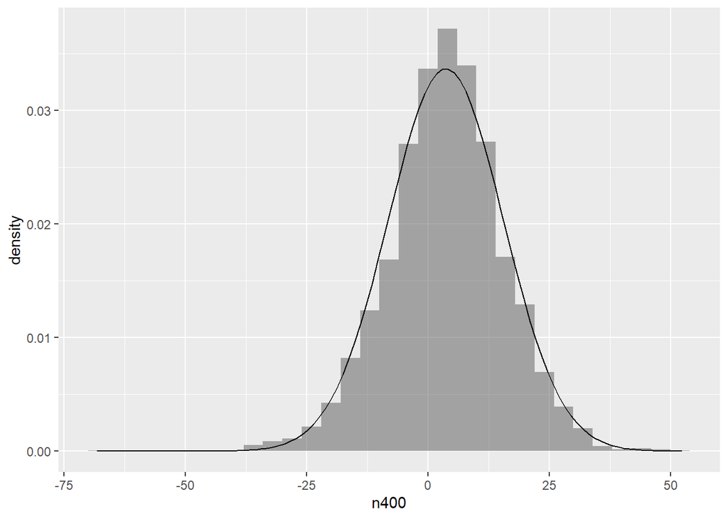

## 1. Complete Pooling Model

Dieses Modell geht von den folgenden Annahmen aus.

- Die EEG-Mittelwerte für das raumzeitliche N400-Fenster sind normalverteilt.
- Die Beobachtungen sind unabhängig.
- Es besteht eine lineare Beziehung zwischen Lückentext und dem EEG-Signal für den Versuch.

Eine normalverteilte Response scheint hier gegeben zu sein, das Modell wird daher wie folgt aussehen

$$\begin{equation}
signal \sim \mathit{Normal}( \alpha + c\_cloze \cdot \beta,\sigma).
\end{equation}$$

Wie immer müssen wir uns auf unser Vorwissen und unsere Fachkenntnisse stützen, um die Prioritäten zu bestimmen!

Graphen, summaries oder einfach ausprobieren!

### Modell bauen

Wir entscheiden uns nun für die folgenden Annahmen hinsichtlich der Verteilung der Daten

$$\begin{equation}
\begin{aligned}
\beta_{0} &\sim \mathit{Normal}(0,10),\\
\beta &\sim \mathit{Normal}(0,10),\\
\sigma &\sim \mathit{Normal}_{+}(0,50).
\end{aligned}
\end{equation}$$

Wir haben hier also eigentlich ein Lineares Regressions Modell, alle parameter sind “fest” da sie unabhängig sind von der Messung selbst (Probant, Messwiederholung etc.).

Unser R-Modell sieht dann wie folgt aus

```r
# Klassische Statistik
m1 <- lm(n400 ~ c_cloze, data = df_eeg)

# Pooling Modell
m2 <- brm(n400 ~ c_cloze,
                   family = gaussian(),
                    prior =
                      c(
                        prior(normal(0, 10), class = Intercept),
                        prior(normal(0, 10), class = b, coef = c_cloze),
                        prior(normal(0, 50), class = sigma)
                      ),
                    data = df_eeg
                  )
```

Vergleichen wir einmal die Modelle

```r
summary(m1)
```

```
##
## Call:
## lm(formula = n400 ~ c_cloze, data = df_eeg)
##
## Residuals:
##     Min      1Q  Median      3Q     Max
## -72.479  -7.352   0.073   7.470  49.685
##
## Coefficients:
##             Estimate Std. Error t value Pr(>|t|)
## (Intercept)   3.6646     0.2208  16.597  < 2e-16 ***
## c_cloze       2.2643     0.5446   4.158 3.31e-05 ***
## ---
## Signif. codes:  0 '***' 0.001 '**' 0.01 '*' 0.05 '.' 0.1 ' ' 1
##
## Residual standard error: 11.81 on 2861 degrees of freedom
## Multiple R-squared:  0.006006,   Adjusted R-squared:  0.005659
## F-statistic: 17.29 on 1 and 2861 DF,  p-value: 3.307e-05
```

```r
summary(m2)
```

```
##  Family: gaussian
##   Links: mu = identity; sigma = identity
## Formula: n400 ~ c_cloze
##    Data: df_eeg (Number of observations: 2863)
##   Draws: 4 chains, each with iter = 2000; warmup = 1000; thin = 1;
##          total post-warmup draws = 4000
##
## Population-Level Effects:
##           Estimate Est.Error l-95% CI u-95% CI Rhat Bulk_ESS Tail_ESS
## Intercept     3.66      0.22     3.24     4.10 1.00     4343     3392
## c_cloze       2.25      0.54     1.18     3.30 1.00     4336     3024
##
## Family Specific Parameters:
##       Estimate Est.Error l-95% CI u-95% CI Rhat Bulk_ESS Tail_ESS
## sigma    11.82      0.16    11.53    12.13 1.00     3691     2719
##
## Draws were sampled using sampling(NUTS). For each parameter, Bulk_ESS
## and Tail_ESS are effective sample size measures, and Rhat is the potential
## scale reduction factor on split chains (at convergence, Rhat = 1).
```

Ist das bayesianische Modell konvergiert? Wie sind die Simulationen gelaufen?

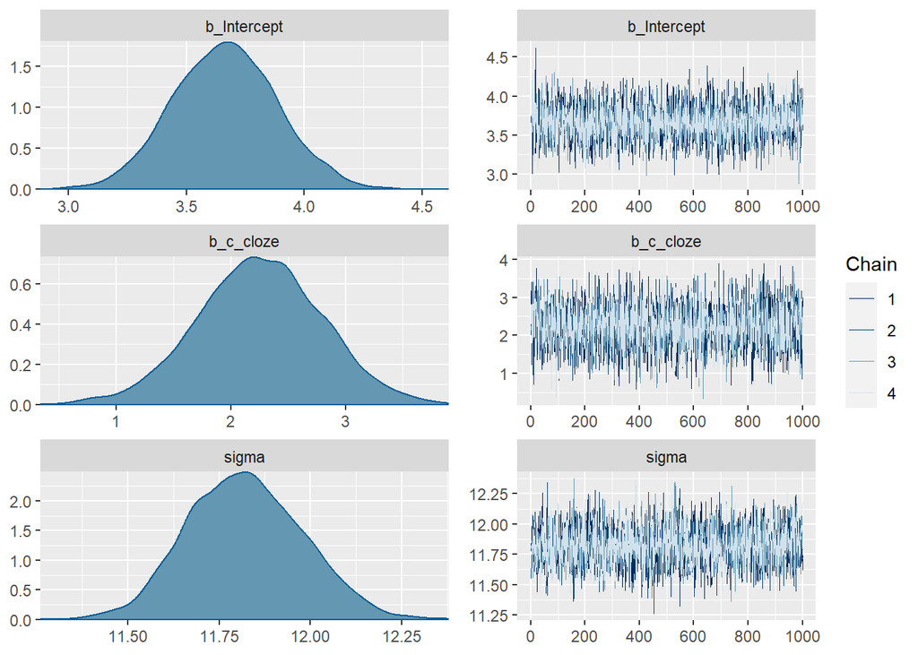

```r
plot(m2)
```

Eine der Annahmen des vorangegangenen Modells ist falsch: Die Beobachtungen sind nicht unabhängig, sie sind nach Probanden geclustert!

Es ist vernünftig anzunehmen, dass die EEG-Signale innerhalb der Probanden ähnlicher sind als zwischen ihnen.

## 2. No pooling Modell

Das folgende Modell geht davon aus, dass jedes Subjekt völlig unabhängig von den anderen ist.

Die neuen Modellannahmen sind nun

- Die EEG-Mittelwerte sind normalverteilt.
- Das Modell eines jeden Probanden wird unabhängig von den anderen Probanden gefittet die Probanden haben keine gemeinsamen Parameter (eine Ausnahme ist die Standardabweichung)
- Es besteht ein linearer Zusammenhang zwischen Lückentext und dem EEG-Signal für den Versuch.

Aber nun, welche Likelihood und Prioren können wir hier wählen?

Die Wahrscheinlichkeitsverteilung ist wie zuvor eine Normalverteilung:

$$\begin{equation}
signal \sim \mathit{Normal}( \alpha_{subj} + c\_cloze \cdot
\beta_{subj},\sigma)
\end{equation}$$

### Modell bauen

$$\begin{equation}
\begin{aligned}
\beta_{0,i} &\sim \mathit{Normal}(0,10)\\
\beta_{i} &\sim \mathit{Normal}(0,10)\\
\sigma &\sim \mathit{Normal}_+(0,50)
\end{aligned}
\end{equation}$$

Wir wollen jetzt für jeden Probanten einen Intercept und einen Slope Parameter geschätzt bekommen. Okay wie machen wir es?

```r
m3 <- brm(n400 ~ 0 + factor(subj) + c_cloze:factor(subj),
          family = gaussian(),
          prior =
            c(
              prior(normal(0, 10), class = b),
              prior(normal(0, 50), class = sigma)
            ),
          data = df_eeg
        )
```

Es ist wichtig, dass der Proband als Faktor und nicht als Zahl behandelt wird.

### Analyse des Modells

Das plotten der Ergebnisse ist hier leider weniger gut, da hier für alle Probanten jeweils ein ergebnis ausgegeben werden würde, als nicht

```r
summary(m3)
plot(m3)
```

Stattdessen bieten sich Funktionen an wie `mcmc_plot()`.

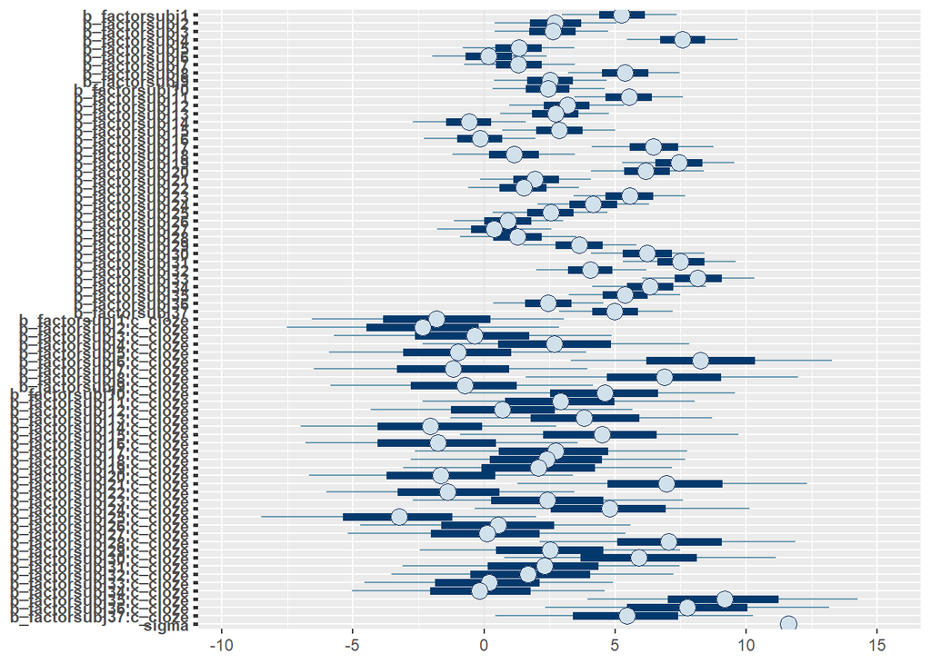

```r
brms::mcmc_plot(m3)
```

Ein Problem des No-Pooling-Modells besteht darin, dass wir die Tatsache, dass die Versuchspersonen dasselbe Experiment durchgeführt haben, völlig außer Acht lassen. Wir passen die Daten eines jeden Probanden an und ignorieren dabei die Informationen, die in den Daten der anderen Probanden enthalten sind.

## 3. Random Intercept und Random Slopes

In dem Modell, das wir als Nächstes gefittet, nehmen wir an, dass es einen Gesamteffekt gibt, der allen Probanden gemeinsam ist, und, was wichtig ist, dass die Parameter aller Probanden aus einer gemeinsamen (normalen) Verteilung stammen. Diese Modellspezifikation führt dazu, dass die Schätzung der Posterioren für jeden Probanden auch von dem beeinflusst wird, was wir über alle Probanden zusammen wissen.

Die Wahrscheinlichkeit beinhaltet nun die Annahme, dass sowohl der Achsenabschnitt als auch die Steigung nach Subjekt angepasst sind.

$$\begin{equation}
signal \sim \mathit{Normal}(\alpha + u_{subj,1} + c\_cloze \cdot
(\beta+ u_{subj,2}),\sigma)
\end{equation}$$

$$\begin{equation}
\begin{aligned}
\beta_{0} &\sim \mathit{Normal}(0,10)\\
\beta &\sim \mathit{Normal}(0,10)\\
b_1 &\sim \mathit{Normal}(0,\tau_{u_1})\\
b_2 &\sim \mathit{Normal}(0,\tau_{u_2})\\
\tau_{u_1} &\sim \mathit{Normal}_+(0,20) \\
\tau_{u_2} &\sim \mathit{Normal}_+(0,20) \\
\sigma &\sim \mathit{Normal}_+(0,50)
\end{aligned}
\end{equation}$$

In diesem Modell hat jedes Subjekt seine eigene Achsenanpassung und Steigungsanpassung. Wenn diese positiv ist, hat das Subjekt ein positiveres EEG-Signal als der große Durchschnittswert. Wenn positiv, wird der Proband eine positivere EEG-Antwort auf eine Änderung von einer Einheit in c_cloze haben als der Gesamtmittelwert (d.h. es wird einen positiveren Effekt der Lückentext-Wahrscheinlichkeit auf die N400 geben). Die Parameter werden manchmal als zufällige Effekte bezeichnet, so dass ein Modell mit festen Effekten und zufälligen Effekten als gemischtes Modell bezeichnet wird.

### Modell bauen

```r
prior_v <-
  c(
    prior(normal(0, 10), class = Intercept),
    prior(normal(0, 10), class = b, coef = c_cloze),
    prior(normal(0, 50), class = sigma),
    prior(normal(0, 20), class = sd, coef = Intercept, group = subj),
    prior(normal(0, 20), class = sd, coef = c_cloze, group = subj)
  )

m4 <- brm(n400 ~ c_cloze + (c_cloze || subj),
                  family=gaussian(),
                  prior = prior_v,
                  data = df_eeg
)
```

```r
summary(m4)
```

```
##  Family: gaussian
##   Links: mu = identity; sigma = identity
## Formula: n400 ~ c_cloze + (c_cloze || subj)
##    Data: df_eeg (Number of observations: 2863)
##   Draws: 4 chains, each with iter = 2000; warmup = 1000; thin = 1;
##          total post-warmup draws = 4000
##
## Group-Level Effects:
## ~subj (Number of levels: 37)
##               Estimate Est.Error l-95% CI u-95% CI Rhat Bulk_ESS Tail_ESS
## sd(Intercept)     2.16      0.37     1.52     2.98 1.00     1494     2005
## sd(c_cloze)       1.75      0.90     0.12     3.49 1.00     1080     1138
##
## Population-Level Effects:
##           Estimate Est.Error l-95% CI u-95% CI Rhat Bulk_ESS Tail_ESS
## Intercept     3.66      0.43     2.80     4.49 1.00     1423     2070
## c_cloze       2.32      0.62     1.09     3.52 1.00     3577     2736
##
## Family Specific Parameters:
##       Estimate Est.Error l-95% CI u-95% CI Rhat Bulk_ESS Tail_ESS
## sigma    11.62      0.16    11.31    11.93 1.00     5879     2816
##
## Draws were sampled using sampling(NUTS). For each parameter, Bulk_ESS
## and Tail_ESS are effective sample size measures, and Rhat is the potential
## scale reduction factor on split chains (at convergence, Rhat = 1).
```

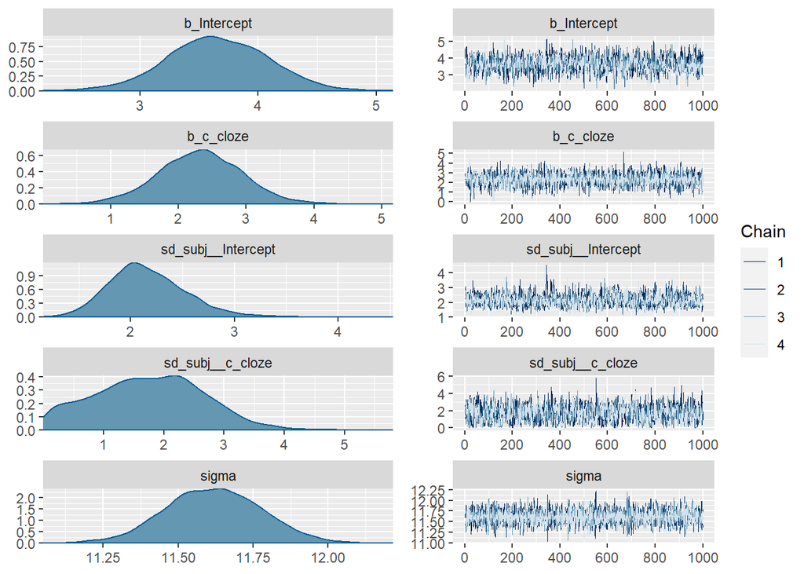

[figure not shown]

```r
plot(m4)
```

Es gibt einen wichtigen Unterschied zwischen dem No-Pooling-Modell und dem Modell der variierenden Achsen und Steigungen, das wir gerade angepasst haben.

- as No-Pooling-Modell passt den Achsenabschnitt und die Steigung jedes einzelnen Probanden unabhängig für jeden Probanden an.
- Im Gegensatz dazu berücksichtigt das Modell der variierenden Achsen und Steigungen die Daten aller Probanden, um die festen Effekte zu berechnen $\beta_0$ und $\beta$ zu berechnen.

## 4. Correlated varying intercept varying slopes model

Modellannahmen:

- Die EEG-Mittelwerte für das räumlich-zeitliche N400-Fenster sind normalverteilt.
- Einige Aspekte der mittleren Signalspannung und des Effekts der Vorhersagbarkeit hängen vom Probanden ab, und diese beiden könnten korreliert sein, d.h. wir nehmen Intercepts und Steigungen auf Gruppenebene an und erlauben eine Korrelation zwischen ihnen nach Probanden.
- Es besteht eine lineare Beziehung zwischen Lückentext und dem EEG-Signal für den Versuch.

### Modell bauen

Die Wahrscheinlichkeit bleibt identisch mit dem Modell, das keine Korrelation zwischen den Achsenabschnitten und Steigungen auf Gruppenebene annimmt

$$\begin{equation}
signal_n \sim \mathit{Normal}(\alpha + u_{subj[n],1} + c\_cloze_n
\cdot (\beta + u_{subj[n],2}),\sigma)
\end{equation}$$

Die Korrelation ist in den Prioritäten für die Anpassungen für den Intercept angegeben $b_1$ und Steigungen $b_2$.

Prior:

$$\begin{equation}
\begin{aligned}
\alpha & \sim \mathit{Normal}(0,10) \\
\beta & \sim \mathit{Normal}(0,10) \\
\sigma &\sim \mathit{Normal}_+(0,50)\\
{\begin{pmatrix}
u_{i,1} \\
u_{i,2}
\end{pmatrix}}
&\sim {\mathcal {N}}
\left(
{\begin{pmatrix}
0\\
0
\end{pmatrix}}
,\boldsymbol{\Sigma_u} \right)
\end{aligned}
\end{equation}$$

Wobei
$$\begin{equation}
\boldsymbol{\Sigma_u} =
{\begin{pmatrix}
\tau_{u_1}^2 & \rho_u \tau_{u_1} \tau_{u_2} \\
\rho_u \tau_{u_1} \tau_{u_2} & \tau_{u_2}^2
\end{pmatrix}}
\end{equation}$$

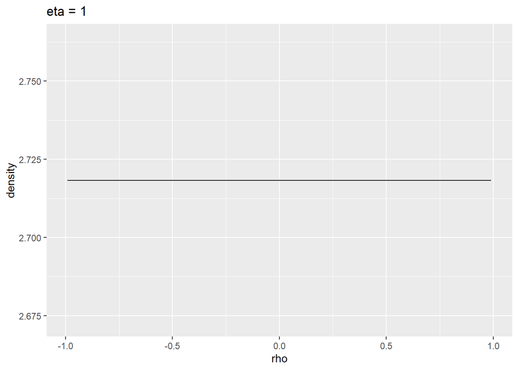

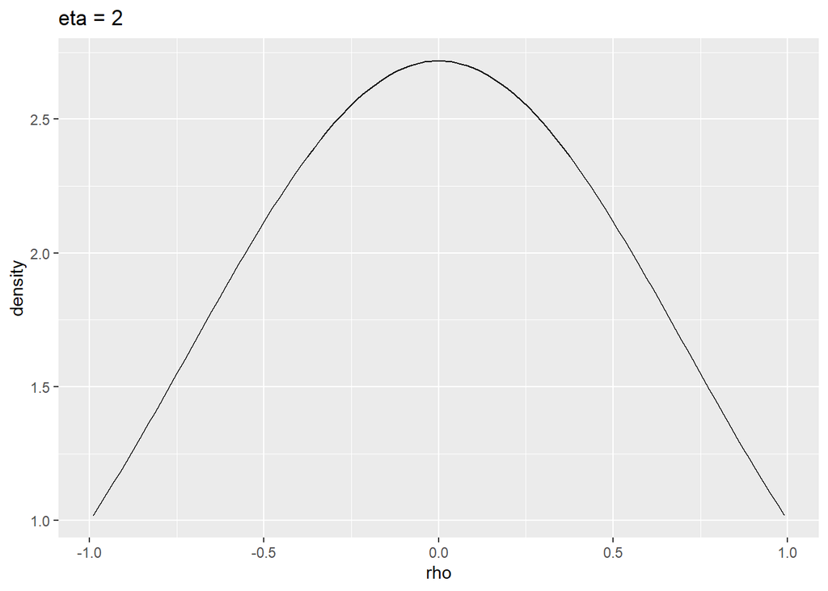

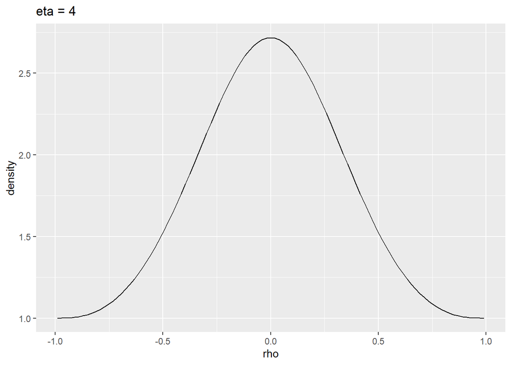

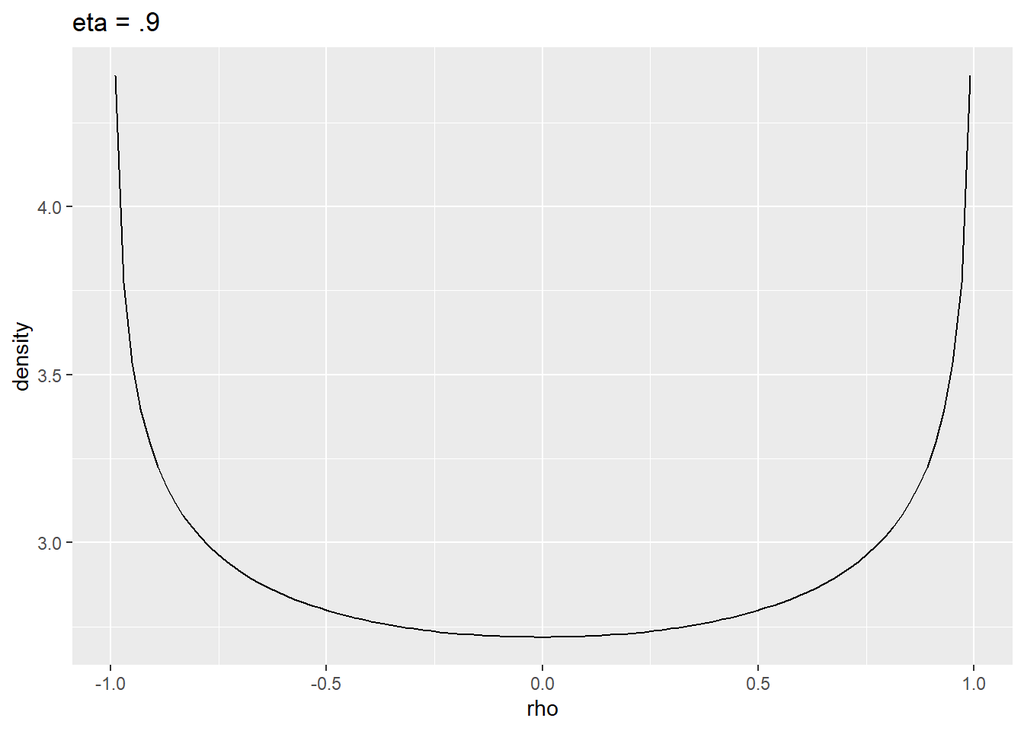

```r
prior_h <- c(
  prior(normal(0, 10), class = Intercept),
  prior(normal(0, 10), class = b, coef = c_cloze),
  prior(normal(0, 50), class = sigma),
  prior(normal(0, 20),
    class = sd, coef = Intercept,
    group = subj
  ),
  prior(normal(0, 20),
    class = sd, coef = c_cloze,
    group = subj
  ),
  prior("lkj(2)", class = cor, group = subj)
)


m5 <- brm(n400 ~ c_cloze + (c_cloze | subj),
  prior = prior_h,
  data = df_eeg
)
```

### Model Analyse

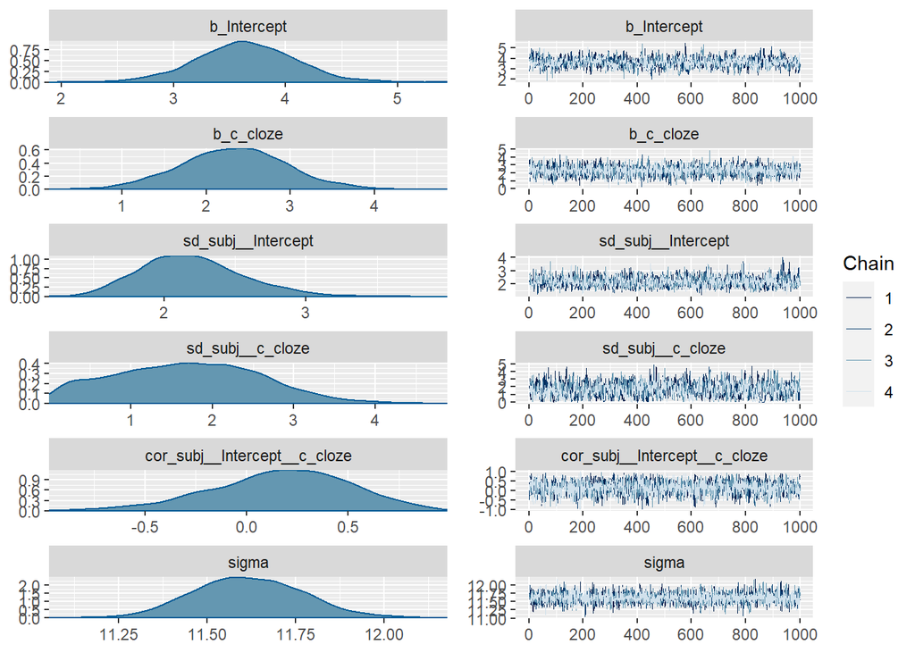

```r
plot(m5, N = 6)
```

## 5. By-subjects and by-items correlated Linear Mixed Model

Modell Annahmen:

- Die Daten sind normalverteilt.
- Einige Aspekte der Intercepts und des Slopes hängen vom Probanden ab, d. h. wir gehen von Achsenabschnitten und Steigungen auf Gruppenebene und einer Korrelation zwischen ihnen nach Probanden aus.
- Einige Aspekte der Intercepts und Effekte der Variablen hängen vom Item ab, d. h. wir gehen von Achsenabschnitten und Steigungen auf Gruppenebene und einer Korrelation zwischen ihnen nach Item aus.
- Es besteht ein linearer Zusammenhang zwischen Lückentext und dem EEG-Signal für den Versuch.

$$\begin{equation}
signal \sim \mathit{Normal}(\alpha + u_{subj,1} + w_{item,1} +
c\_cloze \cdot (\beta + u_{subj,2}+ w_{item,2}), \sigma)
\end{equation}$$

Priors
$$\begin{equation}
\begin{aligned}
\alpha & \sim \mathit{Normal}(0,10) \\
\beta & \sim \mathit{Normal}(0,10) \\
\sigma &\sim \mathit{Normal}_+(0,50)\\
{\begin{pmatrix}
u_{i,1} \\
u_{i,2}
\end{pmatrix}}
&\sim {\mathcal {N}}
\left(
{\begin{pmatrix}
0\\
0
\end{pmatrix}}
,\boldsymbol{\Sigma_u} \right) \\
{\begin{pmatrix}
w_{j,1} \\
w_{j,2}
\end{pmatrix}}
&\sim {\mathcal {N}}
\left(
{\begin{pmatrix}
0\\
0
\end{pmatrix}}
,\boldsymbol{\Sigma_w} \right)
\end{aligned}
\end{equation}$$

Wir haben den Index j hinzugefügt, der jedes Element repräsentiert, wie wir es bei den Subjekten getan haben.

Prior für Covarianzen:

$$\begin{equation}
\begin{aligned}
\boldsymbol{\Sigma_u} & =
{\begin{pmatrix}
\tau_{u_1}^2 & \rho_u \tau_{u_1} \tau_{u_2} \\
\rho_u \tau_{u_1} \tau_{u_2} & \tau_{u_2}^2
\end{pmatrix}}\\
\boldsymbol{\Sigma_w} & =
{\begin{pmatrix}
\tau_{w_1}^2 & \rho_w \tau_{w_1} \tau_{w_2} \\
\rho_w \tau_{w_1} \tau_{w_2} & \tau_{w_2}^2
\end{pmatrix}}
\end{aligned}
\end{equation}$$

### Modell bauen

Wir können auch den Aufruf von brms vereinfachen, wenn wir den Parametern by-subject und by-item die gleichen Prioritäten zuweisen:

```r
prior_sih <-
  c(
    prior(normal(0, 10), class = Intercept),
    prior(normal(0, 10), class = b),
    prior(normal(0, 50), class = sigma),
    prior(normal(0, 20), class = sd),
    prior("lkj(2)", class = cor)
  )


m7 <- brm(n400 ~ c_cloze + (c_cloze | subj) + (c_cloze | item),
          prior = prior_sih,
          data = df_eeg
)
```